# Zoo Mohit2

### Zoo -- Mohit 2

```python
import pandas as pd
import numpy as np

import seaborn as sns
from matplotlib import pyplot as plt
%matplotlib inline

import warnings
warnings.filterwarnings("ignore")

import os
```

```python
print os.listdir(".")
```

```
['.ipynb_checkpoints', 'class.csv', 'Zoo Mohit2.ipynb', 'Zoo+Mohit2.html', 'zoo.csv']
```

```python
animal=pd.read_csv('zoo.csv')
ani_class=pd.read_csv('class.csv')
```

```python
animal.head()
```

|  | animal_name | hair | feathers | eggs | milk | airborne | aquatic | predator | toothed | backbone | breathes | venomous | fins | legs | tail | domestic | catsize | class_type |
| --- | --- | --- | --- | --- | --- | --- | --- | --- | --- | --- | --- | --- | --- | --- | --- | --- | --- | --- |
| 0 | aardvark | 1 | 0 | 0 | 1 | 0 | 0 | 1 | 1 | 1 | 1 | 0 | 0 | 4 | 0 | 0 | 1 | 1 |
| 1 | antelope | 1 | 0 | 0 | 1 | 0 | 0 | 0 | 1 | 1 | 1 | 0 | 0 | 4 | 1 | 0 | 1 | 1 |
| 2 | bass | 0 | 0 | 1 | 0 | 0 | 1 | 1 | 1 | 1 | 0 | 0 | 1 | 0 | 1 | 0 | 0 | 4 |
| 3 | bear | 1 | 0 | 0 | 1 | 0 | 0 | 1 | 1 | 1 | 1 | 0 | 0 | 4 | 0 | 0 | 1 | 1 |
| 4 | boar | 1 | 0 | 0 | 1 | 0 | 0 | 1 | 1 | 1 | 1 | 0 | 0 | 4 | 1 | 0 | 1 | 1 |

```python
print animal.shape
print animal.info()
```

```
(101, 18)
<class 'pandas.core.frame.DataFrame'>
RangeIndex: 101 entries, 0 to 100
Data columns (total 18 columns):
animal_name    101 non-null object
hair           101 non-null int64
feathers       101 non-null int64
eggs           101 non-null int64
milk           101 non-null int64
airborne       101 non-null int64
aquatic        101 non-null int64
predator       101 non-null int64
toothed        101 non-null int64
backbone       101 non-null int64
breathes       101 non-null int64
venomous       101 non-null int64
fins           101 non-null int64
legs           101 non-null int64
tail           101 non-null int64
domestic       101 non-null int64
catsize        101 non-null int64
class_type     101 non-null int64
dtypes: int64(17), object(1)
memory usage: 14.3+ KB
None
```

```python
print "Total distinct animal", animal.animal_name.nunique() , "with details : ", animal.animal_name.unique()
```

```
Total distinct animal 100 with details :  ['aardvark' 'antelope' 'bass' 'bear' 'boar' 'buffalo' 'calf' 'carp'
 'catfish' 'cavy' 'cheetah' 'chicken' 'chub' 'clam' 'crab' 'crayfish'
 'crow' 'deer' 'dogfish' 'dolphin' 'dove' 'duck' 'elephant' 'flamingo'
 'flea' 'frog' 'fruitbat' 'giraffe' 'girl' 'gnat' 'goat' 'gorilla' 'gull'
 'haddock' 'hamster' 'hare' 'hawk' 'herring' 'honeybee' 'housefly' 'kiwi'
 'ladybird' 'lark' 'leopard' 'lion' 'lobster' 'lynx' 'mink' 'mole'
 'mongoose' 'moth' 'newt' 'octopus' 'opossum' 'oryx' 'ostrich' 'parakeet'
 'penguin' 'pheasant' 'pike' 'piranha' 'pitviper' 'platypus' 'polecat'
 'pony' 'porpoise' 'puma' 'pussycat' 'raccoon' 'reindeer' 'rhea' 'scorpion'
 'seahorse' 'seal' 'sealion' 'seasnake' 'seawasp' 'skimmer' 'skua'
 'slowworm' 'slug' 'sole' 'sparrow' 'squirrel' 'starfish' 'stingray' 'swan'
 'termite' 'toad' 'tortoise' 'tuatara' 'tuna' 'vampire' 'vole' 'vulture'
 'wallaby' 'wasp' 'wolf' 'worm' 'wren']
```

```python
print "Total missing"
animal.isnull().sum()
```

```
Total missing
```

```
animal_name    0
hair           0
feathers       0
eggs           0
milk           0
airborne       0
aquatic        0
predator       0
toothed        0
backbone       0
breathes       0
venomous       0
fins           0
legs           0
tail           0
domestic       0
catsize        0
class_type     0
dtype: int64
```

There are no missing, So data si good

```python
animal.describe()
```

|  | hair | feathers | eggs | milk | airborne | aquatic | predator | toothed | backbone | breathes | venomous | fins | legs | tail | domestic | catsize | class_type |
| --- | --- | --- | --- | --- | --- | --- | --- | --- | --- | --- | --- | --- | --- | --- | --- | --- | --- |
| count | 101.000000 | 101.000000 | 101.000000 | 101.000000 | 101.000000 | 101.000000 | 101.000000 | 101.000000 | 101.000000 | 101.000000 | 101.000000 | 101.000000 | 101.000000 | 101.000000 | 101.000000 | 101.000000 | 101.000000 |
| mean | 0.425743 | 0.198020 | 0.584158 | 0.405941 | 0.237624 | 0.356436 | 0.554455 | 0.603960 | 0.821782 | 0.792079 | 0.079208 | 0.168317 | 2.841584 | 0.742574 | 0.128713 | 0.435644 | 2.831683 |
| std | 0.496921 | 0.400495 | 0.495325 | 0.493522 | 0.427750 | 0.481335 | 0.499505 | 0.491512 | 0.384605 | 0.407844 | 0.271410 | 0.376013 | 2.033385 | 0.439397 | 0.336552 | 0.498314 | 2.102709 |
| min | 0.000000 | 0.000000 | 0.000000 | 0.000000 | 0.000000 | 0.000000 | 0.000000 | 0.000000 | 0.000000 | 0.000000 | 0.000000 | 0.000000 | 0.000000 | 0.000000 | 0.000000 | 0.000000 | 1.000000 |
| 25% | 0.000000 | 0.000000 | 0.000000 | 0.000000 | 0.000000 | 0.000000 | 0.000000 | 0.000000 | 1.000000 | 1.000000 | 0.000000 | 0.000000 | 2.000000 | 0.000000 | 0.000000 | 0.000000 | 1.000000 |
| 50% | 0.000000 | 0.000000 | 1.000000 | 0.000000 | 0.000000 | 0.000000 | 1.000000 | 1.000000 | 1.000000 | 1.000000 | 0.000000 | 0.000000 | 4.000000 | 1.000000 | 0.000000 | 0.000000 | 2.000000 |
| 75% | 1.000000 | 0.000000 | 1.000000 | 1.000000 | 0.000000 | 1.000000 | 1.000000 | 1.000000 | 1.000000 | 1.000000 | 0.000000 | 0.000000 | 4.000000 | 1.000000 | 0.000000 | 1.000000 | 4.000000 |
| max | 1.000000 | 1.000000 | 1.000000 | 1.000000 | 1.000000 | 1.000000 | 1.000000 | 1.000000 | 1.000000 | 1.000000 | 1.000000 | 1.000000 | 8.000000 | 1.000000 | 1.000000 | 1.000000 | 7.000000 |

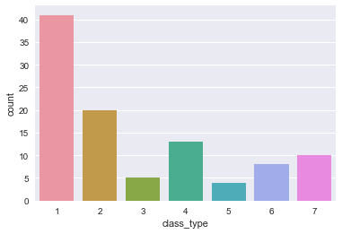

```python
sns.countplot(animal.class_type)
```

```python
animal.groupby(["class_type"])["hair"].count()
```

```
class_type
1    41
2    20
3     5
4    13
5     4
6     8
7    10
Name: hair, dtype: int64
```

```python
animal.legs.unique()
```

```
array([4, 0, 2, 6, 8, 5], dtype=int64)
```

```python
animal.groupby(["legs"])["hair"].count()
```

```
legs
0    23
2    27
4    38
5     1
6    10
8     2
Name: hair, dtype: int64
```

```python
animal[(animal.legs==5)]
```

|  | animal_name | hair | feathers | eggs | milk | airborne | aquatic | predator | toothed | backbone | breathes | venomous | fins | legs | tail | domestic | catsize | class_type |
| --- | --- | --- | --- | --- | --- | --- | --- | --- | --- | --- | --- | --- | --- | --- | --- | --- | --- | --- |
| 85 | starfish | 0 | 0 | 1 | 0 | 0 | 1 | 1 | 0 | 0 | 0 | 0 | 0 | 5 | 0 | 0 | 0 | 7 |

```python
animal[(animal.legs==8)]
```

|  | animal_name | hair | feathers | eggs | milk | airborne | aquatic | predator | toothed | backbone | breathes | venomous | fins | legs | tail | domestic | catsize | class_type |
| --- | --- | --- | --- | --- | --- | --- | --- | --- | --- | --- | --- | --- | --- | --- | --- | --- | --- | --- |
| 53 | octopus | 0 | 0 | 1 | 0 | 0 | 1 | 1 | 0 | 0 | 0 | 0 | 0 | 8 | 0 | 0 | 1 | 7 |
| 72 | scorpion | 0 | 0 | 0 | 0 | 0 | 0 | 1 | 0 | 0 | 1 | 1 | 0 | 8 | 1 | 0 | 0 | 7 |

### Exploratory Data analysis

```python
df=pd.merge(animal,ani_class,how='left', left_on='class_type', right_on='Class_Number')
df.head()
```

|  | animal_name | hair | feathers | eggs | milk | airborne | aquatic | predator | toothed | backbone | ... | fins | legs | tail | domestic | catsize | class_type | Class_Number | Number_Of_Animal_Species_In_Class | Class_Type | Animal_Names |
| --- | --- | --- | --- | --- | --- | --- | --- | --- | --- | --- | --- | --- | --- | --- | --- | --- | --- | --- | --- | --- | --- |
| 0 | aardvark | 1 | 0 | 0 | 1 | 0 | 0 | 1 | 1 | 1 | ... | 0 | 4 | 0 | 0 | 1 | 1 | 1 | 41 | Mammal | aardvark, antelope, bear, boar, buffalo, calf,... |
| 1 | antelope | 1 | 0 | 0 | 1 | 0 | 0 | 0 | 1 | 1 | ... | 0 | 4 | 1 | 0 | 1 | 1 | 1 | 41 | Mammal | aardvark, antelope, bear, boar, buffalo, calf,... |
| 2 | bass | 0 | 0 | 1 | 0 | 0 | 1 | 1 | 1 | 1 | ... | 1 | 0 | 1 | 0 | 0 | 4 | 4 | 13 | Fish | bass, carp, catfish, chub, dogfish, haddock, h... |
| 3 | bear | 1 | 0 | 0 | 1 | 0 | 0 | 1 | 1 | 1 | ... | 0 | 4 | 0 | 0 | 1 | 1 | 1 | 41 | Mammal | aardvark, antelope, bear, boar, buffalo, calf,... |
| 4 | boar | 1 | 0 | 0 | 1 | 0 | 0 | 1 | 1 | 1 | ... | 0 | 4 | 1 | 0 | 1 | 1 | 1 | 41 | Mammal | aardvark, antelope, bear, boar, buffalo, calf,... |

5 rows × 22 columns

```python
df.drop(["Number_Of_Animal_Species_In_Class","Class_Number"],axis=1, inplace=True)
```

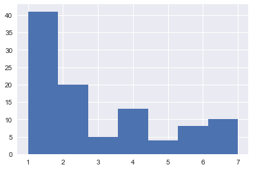

```python
df.class_type.hist(bins=7)
```

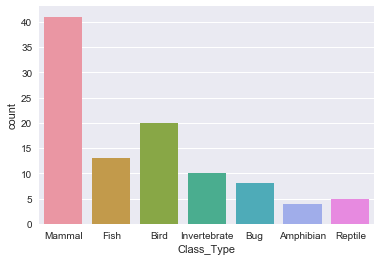

```python
sns.countplot(df.Class_Type)
```

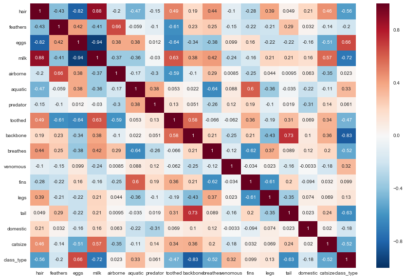

```python
plt.figure(figsize=(15,10))
sns.heatmap(df.corr(),annot=True)
```

```python
cor1=df.corr()
cor2=cor1[cor1 != 1][abs(cor1) > 0.7].dropna(how='all')
cor2
```

|  | hair | feathers | eggs | milk | airborne | aquatic | predator | toothed | backbone | breathes | venomous | fins | legs | tail | domestic | catsize | class_type |
| --- | --- | --- | --- | --- | --- | --- | --- | --- | --- | --- | --- | --- | --- | --- | --- | --- | --- |
| hair | NaN | NaN | -0.817382 | 0.878503 | NaN | NaN | NaN | NaN | NaN | NaN | NaN | NaN | NaN | NaN | NaN | NaN | NaN |
| eggs | -0.817382 | NaN | NaN | -0.938848 | NaN | NaN | NaN | NaN | NaN | NaN | NaN | NaN | NaN | NaN | NaN | NaN | NaN |
| milk | 0.878503 | NaN | -0.938848 | NaN | NaN | NaN | NaN | NaN | NaN | NaN | NaN | NaN | NaN | NaN | NaN | NaN | -0.723683 |
| backbone | NaN | NaN | NaN | NaN | NaN | NaN | NaN | NaN | NaN | NaN | NaN | NaN | NaN | 0.731762 | NaN | NaN | -0.828845 |
| tail | NaN | NaN | NaN | NaN | NaN | NaN | NaN | NaN | 0.731762 | NaN | NaN | NaN | NaN | NaN | NaN | NaN | NaN |
| class_type | NaN | NaN | NaN | -0.723683 | NaN | NaN | NaN | NaN | -0.828845 | NaN | NaN | NaN | NaN | NaN | NaN | NaN | NaN |

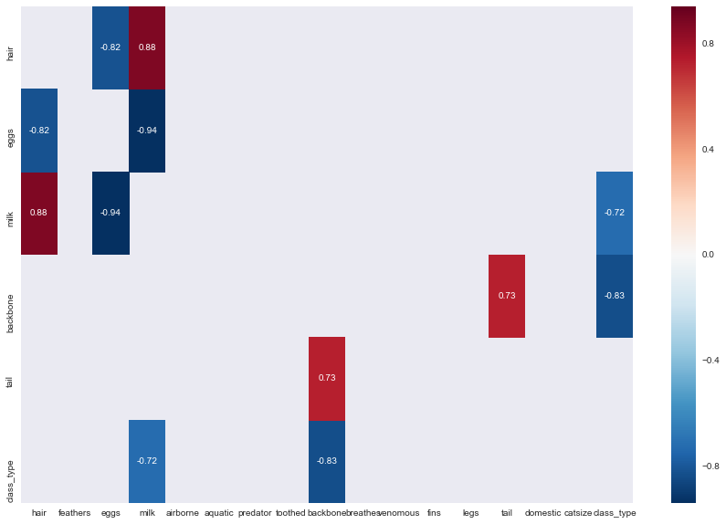

```python
plt.figure(figsize=(15,10))
sns.heatmap(cor2, annot=True)
```

It is too obvious that if "milk" exists, then the animal is mammal; if "feathers" exists, then it should be bird.

```python
df.groupby('Class_Type').mean()
```

| Class_Type | hair | feathers | eggs | milk | airborne | aquatic | predator | toothed | backbone | breathes | venomous | fins | legs | tail | domestic | catsize | class_type |
| --- | --- | --- | --- | --- | --- | --- | --- | --- | --- | --- | --- | --- | --- | --- | --- | --- | --- |
| Amphibian | 0.00000 | 0.0 | 1.00000 | 0.0 | 0.00000 | 1.000000 | 0.750000 | 1.00000 | 1.0 | 1.0 | 0.250000 | 0.000000 | 4.000000 | 0.250000 | 0.000000 | 0.000000 | 5.0 |
| Bird | 0.00000 | 1.0 | 1.00000 | 0.0 | 0.80000 | 0.300000 | 0.450000 | 0.00000 | 1.0 | 1.0 | 0.000000 | 0.000000 | 2.000000 | 1.000000 | 0.150000 | 0.300000 | 2.0 |
| Bug | 0.50000 | 0.0 | 1.00000 | 0.0 | 0.75000 | 0.000000 | 0.125000 | 0.00000 | 0.0 | 1.0 | 0.250000 | 0.000000 | 6.000000 | 0.000000 | 0.125000 | 0.000000 | 6.0 |
| Fish | 0.00000 | 0.0 | 1.00000 | 0.0 | 0.00000 | 1.000000 | 0.692308 | 1.00000 | 1.0 | 0.0 | 0.076923 | 1.000000 | 0.000000 | 1.000000 | 0.076923 | 0.307692 | 4.0 |
| Invertebrate | 0.00000 | 0.0 | 0.90000 | 0.0 | 0.00000 | 0.600000 | 0.800000 | 0.00000 | 0.0 | 0.3 | 0.200000 | 0.000000 | 3.700000 | 0.100000 | 0.000000 | 0.100000 | 7.0 |
| Mammal | 0.95122 | 0.0 | 0.02439 | 1.0 | 0.04878 | 0.146341 | 0.536585 | 0.97561 | 1.0 | 1.0 | 0.000000 | 0.097561 | 3.365854 | 0.853659 | 0.195122 | 0.780488 | 1.0 |
| Reptile | 0.00000 | 0.0 | 0.80000 | 0.0 | 0.00000 | 0.200000 | 0.800000 | 0.80000 | 1.0 | 0.8 | 0.400000 | 0.000000 | 1.600000 | 1.000000 | 0.000000 | 0.200000 | 3.0 |

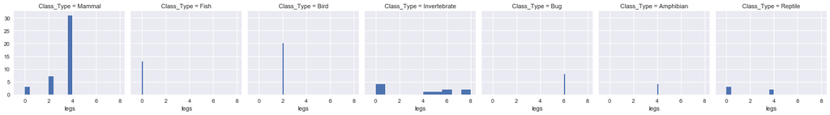

```python
g=sns.FacetGrid(df,col="Class_Type")
g.map(plt.hist,"legs")
```

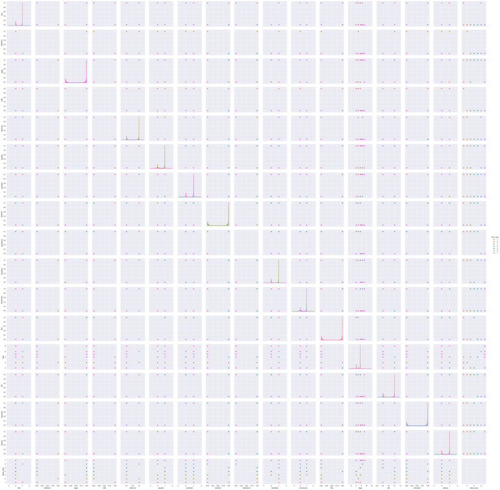

```python
sns.pairplot(data=df, hue='class_type', diag_kind='kde')
```

[output not shown]

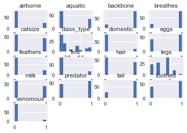

```python
plt.figure(figsize=(30,10))
df.hist()
```

### Predective Modelling

Lets go with the Predective Modelling

```python
from sklearn.linear_model import LogisticRegression
from sklearn.linear_model import Perceptron
from sklearn import svm

from sklearn.neighbors import KNeighborsClassifier
from sklearn.tree import DecisionTreeClassifier

from sklearn.cross_validation import KFold

from sklearn import metrics

from sklearn.cross_validation import train_test_split
```

```python
feature_col=df.columns.difference(['class_type','Class_Type','Animal_Names','animal_name'])
```

### Stratification

When we split the dataset into train and test datasets, the split is completely random. Thus the instances of each class label or outcome in the train or test datasets is random. Thus we may have many instances of class 1 in training data and less instances of class 2 in the training data. So during classification, we may have accurate predictions for class1 but not for class2. Thus we stratify the data, so that we have proportionate data for all the classes in both the training and testing data.

```python
train_x, test_x, train_y, test_y = train_test_split(df[feature_col], df["class_type"], random_state=123,test_size=.3, stratify=df["class_type"])
print "Total Train size x : ", train_x.shape, "And y : ",train_y.shape[0]
print "Total Test size x : ", test_x.shape, "And y : ",test_y.shape[0]
train_x.columns
```

```
Total Train size x :  (70, 16) And y :  70
Total Test size x :  (31, 16) And y :  31
```

```
Index([u'airborne', u'aquatic', u'backbone', u'breathes', u'catsize',
       u'domestic', u'eggs', u'feathers', u'fins', u'hair', u'legs', u'milk',
       u'predator', u'tail', u'toothed', u'venomous'],
      dtype='object')
```

### 1 : SVM (Radial and Linear)

```
Accuracy of  rbf SVM is :  0.935483870968
Accuracy of  linear SVM is :  1.0
```

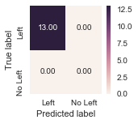

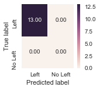

```python
###f,ax=plt.subplots(1,2,figsize=(10,5))
train_x.columns

type=["rbf","linear"]
for i in type:
    model=svm.SVC(kernel=i)
    model.fit(train_x,train_y)
    pred_y=model.predict(test_x)
    print "Accuracy of ", i, "SVM is : ", metrics.accuracy_score(test_y,pred_y)
    cm=metrics.confusion_matrix(test_y,pred_y,[1,0])
    plt.figure(figsize=(2,2))
    sns.heatmap(cm,annot=True,fmt=".2f",xticklabels=["Left","No Left"], yticklabels=["Left","No Left"])
    plt.xlabel('Predicted label')
    plt.ylabel('True label')
```

### 2. Perceptron Method

Perceptron is good for multi-class classification, which might be a good method for us, since we have 7 animal classes.

```
Accuracy Score at Perception Method :  0.967741935484
```

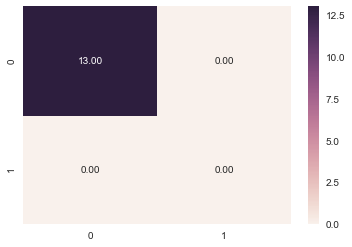

```python
model=Perceptron(eta0=1,random_state=1)
model.fit(train_x,train_y)
pred_y=model.predict(test_x)
print "Accuracy Score at Perception Method : ", metrics.accuracy_score(test_y,pred_y)

cm=metrics.confusion_matrix(test_y,pred_y,[1,0])
sns.heatmap(cm,annot=True, fmt=".2f")
```

### 3. Logistic Regreesion

```
Accuracy score at Logistic Regression :  0.967741935484
```

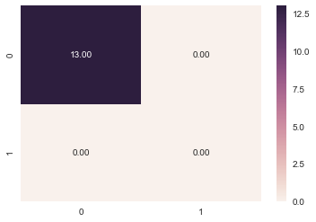

```python
model=LogisticRegression()
model.fit(train_x, train_y)
pred_y=model.predict(test_x)
print "Accuracy score at Logistic Regression : ", metrics.accuracy_score(test_y,pred_y)

cm=metrics.confusion_matrix(test_y,pred_y,[1,0])
sns.heatmap(cm,annot=True, fmt=".2f")
```

### 4 Decision Tree

```python
model=DecisionTreeClassifier()
model.fit(train_x,train_y)
pred_y=model.predict(train_x)
metrics.accuracy_score(train_y,pred_y)
```

```
1.0
```

### 5 K-NN

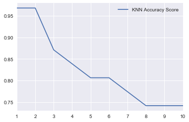

```python
a_ind=range(1,11)
a=pd.Series()
b=[]
for i in range(1,11):
    model=KNeighborsClassifier(n_neighbors=i)
    model.fit(train_x,train_y)
    pred_y=model.predict(test_x)
    b.append(metrics.accuracy_score(test_y, pred_y))
b=pd.DataFrame(b, index=range(1,11))
b.columns=["KNN Accuracy Score"]
b.plot()
```

### In nut shell

```python
abc=[]
classifier=["Linear SVM","Radial SVM","Logistic Regression","KNN","decision tree","Preception"]
models=[svm.SVC(kernel="rbf"), svm.SVC(kernel='linear'), LogisticRegression(), KNeighborsClassifier(n_neighbors=3),
       DecisionTreeClassifier(),Perceptron(random_state=123)]
for i in models:
    model=i
    model.fit(train_x,train_y)
    pred_y=model.predict(test_x)
    abc.append(metrics.accuracy_score(test_y, pred_y))
abc=pd.DataFrame(abc, index=classifier)
abc.columns=["Accuracy Score"]
abc
```

[output not shown]

### Random forest Algorithm

```python
from sklearn.ensemble import RandomForestClassifier

model=RandomForestClassifier(n_estimators=10, random_state=123)
model.fit(train_x, train_y)
pd.Series(model.feature_importances_, index=train_x.columns).sort_values(ascending=False).to_frame()
```

|  | 0 |
| --- | --- |
| hair | 0.165969 |
| milk | 0.137146 |
| legs | 0.126930 |
| feathers | 0.099472 |
| toothed | 0.093759 |
| eggs | 0.073150 |
| fins | 0.072152 |
| backbone | 0.052188 |
| breathes | 0.044414 |
| aquatic | 0.043667 |
| tail | 0.034441 |
| venomous | 0.026709 |
| airborne | 0.014743 |
| predator | 0.011759 |
| catsize | 0.003503 |
| domestic | 0.000000 |

### Cross Validation

Many a times, the data is imbalanced, i.e there may be a high number of class1 instances but less number of other class instances. Thus we should train and test our algorithm on each and every instance of the dataset. Then we can take an average of all the noted accuracies over the dataset.

1)The K-Fold Cross Validation works by first dividing the dataset into k-subsets.

2)Let's say we divide the dataset into (k=5) parts. We reserve 1 part for testing and train the algorithm over the 4 parts.

3)We continue the process by changing the testing part in each iteration and training the algorithm over the other parts. The accuracies and errors are then averaged to get a average accuracy of the algorithm.

This is called K-Fold Cross Validation.

4)An algorithm may underfit over a dataset for some training data and sometimes also overfit the data for other training set. Thus with cross-validation, we can achieve a generalised model.

```python
from sklearn.model_selection import cross_val_score
from sklearn.model_selection import KFold #for K-fold cross validation
```

```python
XYZ=[]
Accuracy=[]

abc=[]
classifier=["Linear SVM","Radial SVM","Logistic Regression","KNN","decision tree","Preception"]
models=[svm.SVC(kernel="rbf"), svm.SVC(kernel='linear'), LogisticRegression(multi_class='multinomial', solver='newton-cg'), KNeighborsClassifier(n_neighbors=3),
       DecisionTreeClassifier(),Perceptron(random_state=123)]
for i in models:
    model=i
    cv_score=cross_val_score(model,train_x,train_y,cv=10, scoring="accuracy")
    XYZ.append(cv_score.mean())
    Accuracy.append(cv_score)
XYZ=pd.DataFrame(XYZ, index=classifier)
XYZ.columns=["Mean Score post Cross Valiadation"]
XYZ
```

[output not shown]

```python
XYZ=[]
Accuracy=[]
Std=[]
kfold = KFold(n_splits=10, random_state=22) # k=10, split the data into 10 equal parts
classifier=["Linear SVM","Radial SVM","Logistic Regression","KNN","decision tree","Preception"]
models=[svm.SVC(kernel="rbf"), svm.SVC(kernel='linear'), LogisticRegression(multi_class='multinomial', solver='newton-cg'), KNeighborsClassifier(n_neighbors=3),
       DecisionTreeClassifier(),Perceptron(random_state=123)]
for i in models:
    model=i
    cv_score=cross_val_score(model, train_x, train_y, cv=kfold, scoring="accuracy")
    XYZ.append(cv_score.mean())
    Std.append(cv_score.std())
    Accuracy.append(cv_score)
new_model=pd.DataFrame({"cv mean": XYZ, "Std" : Std}, index=classifier)
new_model
```

[output not shown]

```python
pd.DataFrame(Accuracy)
```

|  | 0 | 1 | 2 | 3 | 4 | 5 | 6 | 7 | 8 | 9 |
| --- | --- | --- | --- | --- | --- | --- | --- | --- | --- | --- |
| 0 | 0.7 | 0.8 | 0.8 | 1.000 | 1.0 | 1.000000 | 0.833333 | 1.0 | 1.0 | 1.0 |
| 1 | 0.8 | 0.9 | 1.0 | 0.875 | 1.0 | 1.000000 | 1.000000 | 1.0 | 1.0 | 1.0 |
| 2 | 0.8 | 0.9 | 0.9 | 0.875 | 1.0 | 1.000000 | 1.000000 | 1.0 | 1.0 | 1.0 |
| 3 | 0.8 | 0.8 | 0.9 | 0.875 | 1.0 | 1.000000 | 0.833333 | 1.0 | 1.0 | 1.0 |
| 4 | 0.9 | 0.8 | 1.0 | 0.875 | 1.0 | 1.000000 | 1.000000 | 1.0 | 1.0 | 1.0 |
| 5 | 0.8 | 1.0 | 0.9 | 0.750 | 1.0 | 0.857143 | 1.000000 | 1.0 | 1.0 | 1.0 |

### Ensembling

Ensemble methods are techniques that create multiple models and then combine them to produce improved results. Ensemble methods usually produces more accurate solutions than a single model would. The models used to create such ensemble models are called ‘base models’.

We will do ensembling with the Voting Ensemble. Voting is one of the simplest ways of combining the predictions from multiple machine learning algorithms. It works by first creating two or more standalone models from your training dataset. A Voting Classifier can then be used to wrap your models and average the predictions of the sub-models when asked to make predictions for new data.

We will be using weighted Voting Classifier. We will assign to the classifiers according to their accuracies. So the classifier with single accuracy will be assigned the highest weight and so on.

```python
Radial_SVM=svm.SVC(kernel='rbf', C=0.1, gamma=10, probability=True )
LR=LogisticRegression(C=0.1,multi_class='multinomial', solver='newton-cg')
DT=DecisionTreeClassifier()
```

```python
from sklearn.ensemble import VotingClassifier
```

```python
voting_ensemble_SVM_LR=VotingClassifier(estimators=[("Radial SVM",Radial_SVM),
                                                    ("Logistic Regression",LR)],
                                        voting='soft', weights=[2,1]).fit(train_x,train_y)
voting_ensemble_SVM_LR.score(test_x,test_y)
```

```
0.67741935483870963
```

```python
voting_ensemble_SVM_DT=VotingClassifier(estimators=[("Radial SVM",Radial_SVM),
                                                    ("Decision Tree",DT)],
                                        voting='soft', weights=[2,1]).fit(train_x,train_y)
voting_ensemble_SVM_DT.score(test_x,test_y)
```

```
0.967741935483871
```

```python
voting_ensemble_LR_DT=VotingClassifier(estimators=[("Decision Tree",DT),
                                                   ("Logistic Regression",LR)],
                                      voting='soft', weights=[2,1]).fit(train_x,train_y)
voting_ensemble_LR_DT.score(test_x,test_y)
```

```
0.967741935483871
```

```python
voting_ensemble_LR_DT_SVM=VotingClassifier(estimators=[("Decision Tree",DT),
                                                       ("Logistic Regression",LR),
                                                       ("Radial SVM",Radial_SVM)],
                                           voting="soft", weights=[3,2,1]).fit(train_x,train_y)
print "Ensemble model with all three classifier is :", voting_ensemble_LR_DT_SVM.score(test_x,test_y)
```

```
Ensemble model with all three classifier is : 0.967741935484
```